# STAT 231: Problem Set 2B

Vaibhav Shah

due by 5 PM on Friday, March 5

Series B homework assignments are designed to help you further ingest and practice the material covered in class over the past week(s). You are encouraged to work with other students, but all code must be written by you and you must indicate below who you discussed the assignment with (if anyone).

# If you discussed this assignment with any of your peers, please list who here:

> ANSWER:

# MDSR Exercise 4.14 (modified)

Use the `Pitching` data frame from the `Lahman` package to identify every pitcher in baseball history who has accumulated at least 300 wins (`W`) and at least 3,000 strikeouts (`SO`).

1. How many pitchers meet this criteria?

> ANSWER: There are ten players who have met the criteria.

```r
library(Lahman)
Beasts <- Pitching %>% group_by(playerID) %>% summarize(tWins = sum(W), tSO = sum(SO)) %>% filter(tWins>300 & tSO > 3000)
Beasts
```

| playerID | tWins | tSO |
| --- | --- | --- |
| carltst01 | 329 | 4136 |
| clemero02 | 354 | 4672 |
| johnsra05 | 303 | 4875 |
| johnswa01 | 417 | 3509 |
| maddugr01 | 355 | 3371 |
| niekrph01 | 318 | 3342 |
| perryga01 | 314 | 3534 |
| ryanno01 | 324 | 5714 |
| seaveto01 | 311 | 3640 |
| suttodo01 | 324 | 3574 |

2. Which of these pitchers had the most accumulated strikeouts? How many strikeouts had he accumulated? What is the most strikeouts he had in one season?

> ANSWER: ryanno01 has the most strikeouts at 5714. He had his peak year for strikeouts in 1973, striking out batters 383 times.

```r
Ryan <- Pitching %>% filter(playerID == "ryanno01") %>% arrange(desc(SO))
Ryan
```

| playerID | yearID | stint | teamID | lgID | W | L | G | GS | CG | SHO | SV | IPouts | H | ER | HR | BB | SO | BAOpp | ERA | IBB | WP | HBP | BK | BFP | GF | R | SH | SF | GIDP |
| --- | --- | --- | --- | --- | --- | --- | --- | --- | --- | --- | --- | --- | --- | --- | --- | --- | --- | --- | --- | --- | --- | --- | --- | --- | --- | --- | --- | --- | --- |
| ryanno01 | 1973 | 1 | CAL | AL | 21 | 16 | 41 | 39 | 26 | 4 | 1 | 978 | 238 | 104 | 18 | 162 | 383 | 0.203 | 2.87 | 2 | 15 | 7 | 0 | 1355 | 2 | 113 | 7 | 7 | 24 |
| ryanno01 | 1974 | 1 | CAL | AL | 22 | 16 | 42 | 41 | 26 | 3 | 0 | 998 | 221 | 107 | 18 | 202 | 367 | 0.190 | 2.89 | 3 | 9 | 9 | 0 | 1392 | 1 | 127 | 12 | 4 | 24 |
| ryanno01 | 1977 | 1 | CAL | AL | 19 | 16 | 37 | 37 | 22 | 4 | 0 | 897 | 198 | 92 | 12 | 204 | 341 | 0.193 | 2.77 | 7 | 21 | 9 | 3 | 1272 | 0 | 110 | 22 | 10 | 21 |
| ryanno01 | 1972 | 1 | CAL | AL | 19 | 16 | 39 | 39 | 20 | 9 | 0 | 852 | 166 | 72 | 14 | 157 | 329 | 0.171 | 2.28 | 4 | 18 | 10 | 0 | 1154 | 0 | 80 | 11 | 3 | NA |
| ryanno01 | 1976 | 1 | CAL | AL | 17 | 18 | 39 | 39 | 21 | 7 | 0 | 853 | 193 | 106 | 13 | 183 | 327 | 0.195 | 3.36 | 2 | 5 | 5 | 2 | 1196 | 0 | 117 | 13 | 4 | 12 |
| ryanno01 | 1989 | 1 | TEX | AL | 16 | 10 | 32 | 32 | 6 | 2 | 0 | 718 | 162 | 85 | 17 | 98 | 301 | 0.187 | 3.20 | 3 | 19 | 9 | 1 | 988 | 0 | 96 | 9 | 5 | 4 |
| ryanno01 | 1987 | 1 | HOU | NL | 8 | 16 | 34 | 34 | 0 | 0 | 0 | 635 | 154 | 65 | 14 | 87 | 270 | 0.200 | 2.76 | 2 | 10 | 4 | 2 | 873 | 0 | 75 | 9 | 1 | 6 |
| ryanno01 | 1978 | 1 | CAL | AL | 10 | 13 | 31 | 31 | 14 | 3 | 0 | 704 | 183 | 97 | 12 | 148 | 260 | 0.220 | 3.72 | 7 | 13 | 3 | 2 | 1008 | 0 | 106 | 11 | 14 | 18 |
| ryanno01 | 1982 | 1 | HOU | NL | 16 | 12 | 35 | 35 | 10 | 3 | 0 | 751 | 196 | 88 | 20 | 109 | 245 | 0.213 | 3.16 | 3 | 18 | 8 | 2 | 1050 | 0 | 100 | 9 | 3 | 12 |
| ryanno01 | 1990 | 1 | TEX | AL | 13 | 9 | 30 | 30 | 5 | 2 | 0 | 612 | 137 | 78 | 18 | 74 | 232 | 0.188 | 3.44 | 2 | 9 | 7 | 1 | 818 | 0 | 86 | 3 | 5 | 5 |

[output cut: 17 more lines]

# MDSR Exercise 4.17 (modified)

1. The Violations data set in the `mdsr` package contains information regarding the outcome of health inspections in New York City. Use these data to calculate the median violation score by zipcode and dba for zipcodes in Manhattan. What pattern (if any) do you see between the number of inspections and the median score? Generate a visualization to support your response.

> ANSWER: There isn’t a very noticeable association. Althougth you can see that as inspection count increases past a certain point, there are no very low scores since these people most likely have to maintain as they are held more liable. This is why variation shrinks dramatically in the range of scores as inspection count increases.

```r
library(mdsr)
Violate <- Violations %>% filter(!is.na(score)) %>% group_by(dba, zipcode) %>% summarize(InspectCt = n(), MedScore = median(score))
```

```r
inspectionmap <- ggplot(data = Violate) + geom_point(mapping = aes(y = MedScore, x = InspectCt))
Violate
```

| dba | zipcode | InspectCt | MedScore |
| --- | --- | --- | --- |
| ''W'' CAFE | 10018 | 23 | 22.0 |
| (LEWIS DRUG STORE) LOCANDA VINI E OLII | 11238 | 17 | 20.0 |
| (LIBRARY) FOUR & TWENTY BLACKBIRDS | 11238 | 9 | 9.0 |
| (PUBLIC FARE) 81st street and central park west (Delacorte Theatre) | 10019 | 19 | 19.0 |
| @NINE | 10036 | 50 | 14.0 |
| / L'ECOLE | 10013 | 15 | 19.0 |
| #1 GARDEN CHINESE | 11215 | 24 | 21.0 |
| #1 SABOR LATINO RESTAURANT | 10466 | 39 | 21.0 |
| $1 PIZZA $2 BEER | 10012 | 40 | 17.0 |
| 1 2 3 BURGER SHOT BEER | 10019 | 18 | 20.0 |

[output cut: 9990 more lines]

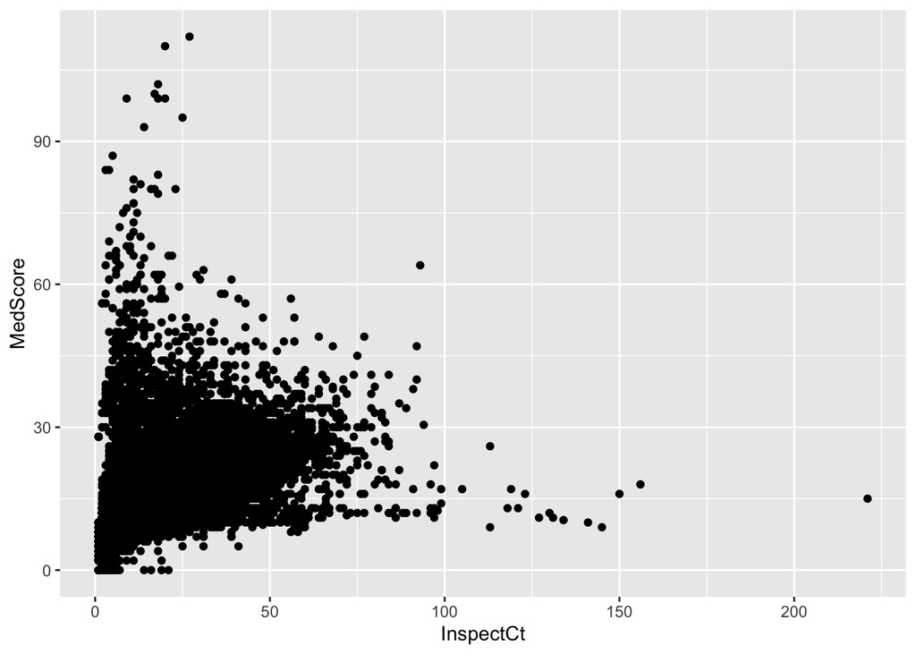

```r
inspectionmap
```

2. In your visualization in part (a), there should be at least a few points that stand out as outliers. For *one of the outliers*, add text to the outlier identifying what business it is and an arrow pointing from the text to the observation. First, you may want to `filter` to identify the name of the business (so you know what text to add to the plot).

(Can’t remember how to create a curved arrow in `ggplot`? The answers to [this question](https://stackoverflow.com/questions/38008863/how-to-draw-a-nice-arrow-in-ggplot2/61383034) on Stack Exchange may help. Can’t remember how to add text to the plot in `ggplot`? Check out the text examples with `annotate` [here](https://ggplot2.tidyverse.org/reference/annotate.html), or answers to [this question](https://stackoverflow.com/questions/14351608/color-one-point-and-add-an-annotation-in-ggplot2/14351810) that use `geom_text`.)

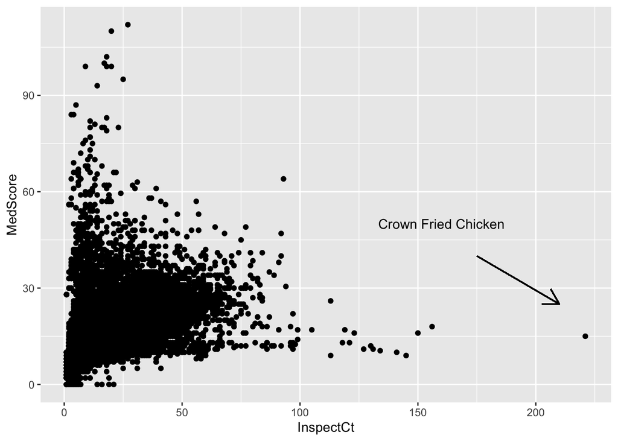

```r
inspectionmap+ geom_segment(aes(x = 175, y = 40, xend = 210, yend = 25),
                  arrow = arrow(length = unit(0.5, "cm"))) + annotate("text", x = 160, y = 50, label = "Crown Fried Chicken")
```

# MDSR Exercise 5.7

Generate the code to convert the data frame shown with this problem in the textbook (on page 130, and shown below) to wide format (i.e., the result table). Hint: use `gather()` in conjunction with `spread()`; OR `pivot_longer()` in conjunction with `pivot_wider()`.

```r
FakeDataLong <- data.frame(grp = c("A","A","B", "B")
                           , sex = c("F", "M", "F", "M")
                           , meanL = c(0.22, 0.47, 0.33, 0.55)
                           , sdL = c(0.11, 0.33, 0.11, 0.31)
                           , meanR = c(0.34, 0.57, 0.40, 0.65)
                           , sdR = c(0.08, 0.33, 0.07, 0.27))

FakeDataLong
```

| grp | sex | meanL | sdL | meanR | sdR |
| --- | --- | --- | --- | --- | --- |
| A | F | 0.22 | 0.11 | 0.34 | 0.08 |
| A | M | 0.47 | 0.33 | 0.57 | 0.33 |
| B | F | 0.33 | 0.11 | 0.40 | 0.07 |
| B | M | 0.55 | 0.31 | 0.65 | 0.27 |

```r
library(stringr)
FakeDataShort <- FakeDataLong %>%
   mutate(NmeanL = str_c(sex, "meanL"), NsdL = str_c(sex, "sdL"), NmeanR = str_c(sex, "meanR"), NsdR = str_c(sex, "sdR"))
FakeDataShort[2] <- NULL
FakeDataShort <- FakeDataShort %>%
   pivot_wider(names_from = NmeanL, values_from = meanL, names_sep="") %>%
  pivot_wider(names_from = NsdL, values_from = sdL, names_sep="") %>%
  pivot_wider(names_from = NmeanR, values_from = meanR, names_sep="") %>%
  pivot_wider(names_from = NsdR, values_from = sdR, names_sep="")



FakeDataShort %>% group_by(grp) %>% summarize(F.meanL=max(FmeanL,na.rm=TRUE), M.meanL=max(MmeanL,na.rm=TRUE), F.sdL=max(FsdL,na.rm=TRUE), M.sdL=max(MsdL,na.rm=TRUE), F.meanR=max(FmeanR,na.rm=TRUE), M.meanR=max(MmeanR,na.rm=TRUE), F.sdR=max(FsdR,na.rm=TRUE), M.sdR=max(MsdR,na.rm=TRUE),)
```

|  | grp | F.meanL | M.meanL | F.sdL | M.sdL | F.meanR | M.meanR | F.sdR | M.sdR |
| --- | --- | --- | --- | --- | --- | --- | --- | --- | --- |
| 1 | A | 0.22 | 0.47 | 0.11 | 0.33 | 0.34 | 0.57 | 0.08 | 0.33 |
| 2 | B | 0.33 | 0.55 | 0.11 | 0.31 | 0.40 | 0.65 | 0.07 | 0.27 |

# PUG Brainstorming

What topics or questions are you interested in exploring related to your PUG theme? Dream big here. Don’t worry about whether there is data out there that’s available and accessible that you could use to address your questions/topics. Just brainstorm some ideas that get you excited. Then, email your PUG team with your ideas. Title the email “PS2B Brainstorming: PUG [#] [Topic]” and CC me (kcorreia@amherst.edu) on the email. If another PUG member already initiated the email, reply all to their email.

If you don’t remember your PUG # and Topic, please see the file “PUGs” on the Moodle page under this week.

If you don’t know your PUG members email address, go to the class’s Google group conversations (e.g., by clicking the link “Link to Google group conversations” at the top of our Moodle course page). Then, on the navigation panel (left hand side), select “Members”.

> ANSWER: Do not write anything here. Email your ideas to your PUG team and me in a message titled “PS2B Brainstorming: PUG [#] [Topic]”.